# 161.324 Data Mining

Assignment 2, 2026

Emma Bridge

```r
# Add any other packages you need to load here.
library(tidyverse)
library(tidymodels)
library(skimr)
library(GGally)
library(rpart)
library(randomForest)
library(discrim)
library(kknn)

# Read in the data
property.train <- read_csv("https://www.massey.ac.nz/~jcmarsha/161324/assessment/data/property_train_val.csv")
property.test <- read_csv("https://www.massey.ac.nz/~jcmarsha/161324/assessment/data/property_test.csv")
wheat.train <- read_csv("https://www.massey.ac.nz/~jcmarsha/161324/assessment/data/wheat_train_val.csv") |>
  mutate(variety = factor(variety))
wheat.test <- read_csv("https://www.massey.ac.nz/~jcmarsha/161324/assessment/data/wheat_test.csv")
```

Replace `YOUR NAME HERE` in the author field before knitting. Save your final HTML report as `report_studentid.html`.

## Exercise 1: Property Value Prediction

Use property_train_val.csv to build one or more prediction models for price_per_unit, then predict price_per_unit for every row in property_test.csv.

property_train_val.csv contains 310 labelled observations. property_test.csv contains 104 unlabelled observations.

```r
set.seed(1414)
split <- initial_split(property.train, prop= 3/4)
train <- training(split)
test  <- testing(split)

skim(train)
```

Data summary

| Name | train |
| --- | --- |
| Number of rows | 232 |
| Number of columns | 7 |
| _______________________ |  |
| Column type frequency: |  |
| numeric | 7 |
| ________________________ |  |
| Group variables | None |

**Variable type: numeric**

| skim_variable | n_missing | complete_rate | mean | sd | p0 | p25 | p50 | p75 | p100 | hist |
| --- | --- | --- | --- | --- | --- | --- | --- | --- | --- | --- |
| sale_time | 0 | 1 | 2013.15 | 0.28 | 2012.67 | 2012.92 | 2013.17 | 2013.42 | 2013.58 | ▆▅▅▅▇ |
| property_age | 0 | 1 | 17.56 | 11.22 | 0.00 | 9.62 | 16.20 | 27.70 | 42.70 | ▆▇▅▅▃ |
| transit_distance | 0 | 1 | 1122.52 | 1300.85 | 23.38 | 322.51 | 492.23 | 1565.80 | 6488.02 | ▇▂▁▁▁ |
| nearby_stores | 0 | 1 | 3.91 | 2.95 | 0.00 | 1.00 | 4.00 | 6.00 | 10.00 | ▇▃▆▂▂ |
| latitude | 0 | 1 | 24.97 | 0.01 | 24.93 | 24.96 | 24.97 | 24.98 | 25.00 | ▁▃▇▇▁ |
| longitude | 0 | 1 | 121.53 | 0.02 | 121.47 | 121.53 | 121.54 | 121.54 | 121.57 | ▁▁▂▇▁ |
| price_per_unit | 0 | 1 | 37.31 | 13.61 | 7.60 | 26.60 | 37.45 | 45.47 | 117.50 | ▅▇▂▁▁ |

```r
summary(train)
```

```
##    sale_time     property_age    transit_distance  nearby_stores
##  Min.   :2013   Min.   : 0.000   Min.   :  23.38   Min.   : 0.000
##  1st Qu.:2013   1st Qu.: 9.625   1st Qu.: 322.51   1st Qu.: 1.000
##  Median :2013   Median :16.200   Median : 492.23   Median : 4.000
##  Mean   :2013   Mean   :17.561   Mean   :1122.52   Mean   : 3.914
##  3rd Qu.:2013   3rd Qu.:27.700   3rd Qu.:1565.80   3rd Qu.: 6.000
##  Max.   :2014   Max.   :42.700   Max.   :6488.02   Max.   :10.000
##     latitude       longitude     price_per_unit
##  Min.   :24.93   Min.   :121.5   Min.   :  7.60
##  1st Qu.:24.96   1st Qu.:121.5   1st Qu.: 26.60
##  Median :24.97   Median :121.5   Median : 37.45
##  Mean   :24.97   Mean   :121.5   Mean   : 37.31
##  3rd Qu.:24.98   3rd Qu.:121.5   3rd Qu.: 45.48
##  Max.   :25.00   Max.   :121.6   Max.   :117.50
```

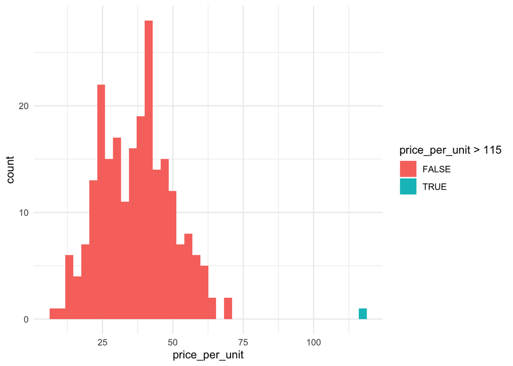

```r
ggplot(train)+
  aes(x=price_per_unit, fill = price_per_unit > 115) +
  geom_histogram(bins = 40) +
  theme_minimal()
```

```r
train_no_outlier <- train |> filter(price_per_unit < 100)

cor(train)
```

```
##                    sale_time property_age transit_distance nearby_stores
## sale_time         1.00000000   0.04855187       0.12595871    0.02487153
## property_age      0.04855187   1.00000000       0.08084116   -0.02868877
## transit_distance  0.12595871   0.08084116       1.00000000   -0.56720653
## nearby_stores     0.02487153  -0.02868877      -0.56720653    1.00000000
## latitude          0.01034799   0.03416869      -0.57585380    0.47177543
## longitude        -0.10098834  -0.10378165      -0.79133167    0.37643495
## price_per_unit    0.05751294  -0.27639864      -0.62628312    0.50680675
##                     latitude  longitude price_per_unit
## sale_time         0.01034799 -0.1009883     0.05751294
## property_age      0.03416869 -0.1037816    -0.27639864
## transit_distance -0.57585380 -0.7913317    -0.62628312
## nearby_stores     0.47177543  0.3764349     0.50680675
## latitude          1.00000000  0.3491628     0.54427135
## longitude         0.34916283  1.0000000     0.45229152
## price_per_unit    0.54427135  0.4522915     1.00000000
```

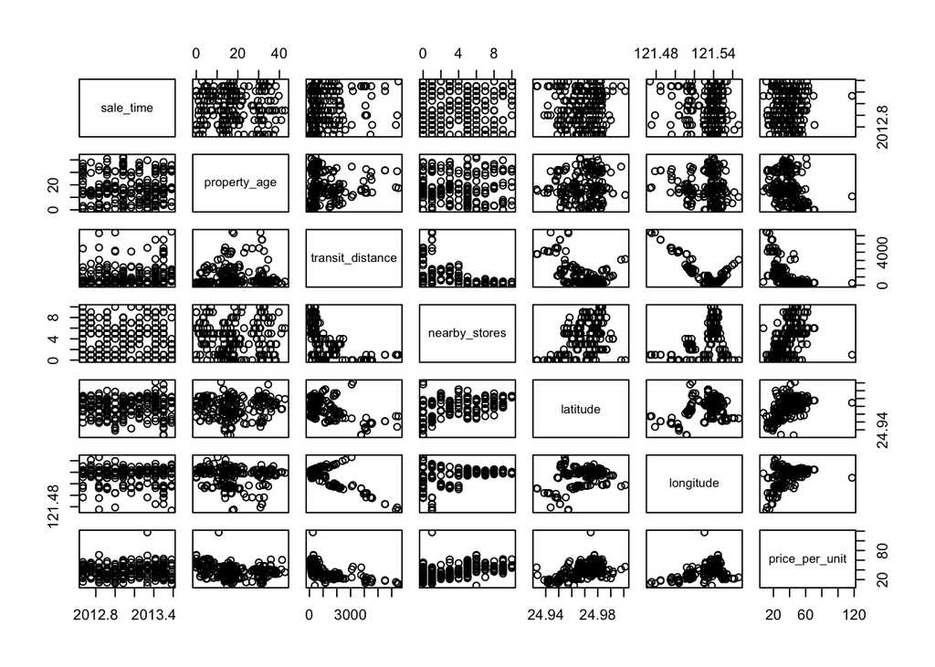

```r
pairs(train)
```

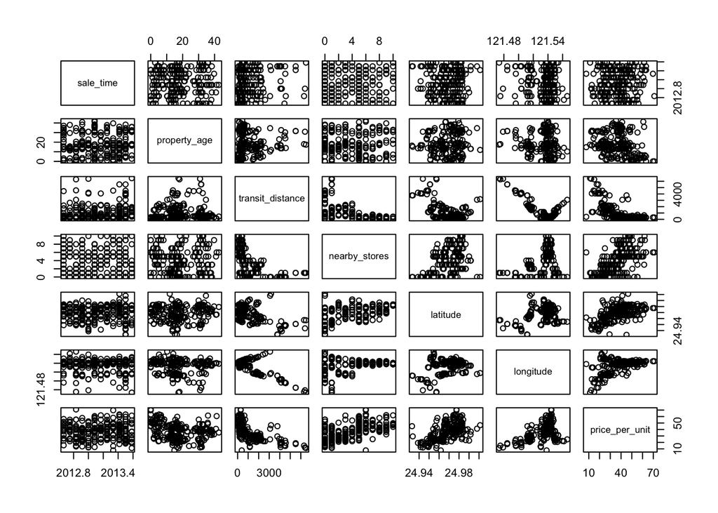

```r
pairs(train_no_outlier)
```

##Linear Model Prediction

```r
#All data
lm_model1 <- lm(price_per_unit ~ ., data = train)
summary(lm_model1)
```

```
##
## Call:
## lm(formula = price_per_unit ~ ., data = train)
##
## Residuals:
##     Min      1Q  Median      3Q     Max
## -34.227  -5.617  -1.035   4.059  73.573
##
## Coefficients:
##                    Estimate Std. Error t value Pr(>|t|)
## (Intercept)      -1.360e+04  9.338e+03  -1.457  0.14661
## sale_time         5.447e+00  2.247e+00   2.425  0.01611 *
## property_age     -3.109e-01  5.555e-02  -5.596 6.34e-08 ***
## transit_distance -4.382e-03  9.815e-04  -4.465 1.27e-05 ***
## nearby_stores     7.198e-01  2.633e-01   2.734  0.00675 **
## latitude          2.773e+02  6.428e+01   4.315 2.39e-05 ***
## longitude        -3.492e+01  6.526e+01  -0.535  0.59312
## ---
## Signif. codes:  0 '***' 0.001 '**' 0.01 '*' 0.05 '.' 0.1 ' ' 1
##
## Residual standard error: 9.384 on 225 degrees of freedom
## Multiple R-squared:  0.537,  Adjusted R-squared:  0.5246
## F-statistic: 43.49 on 6 and 225 DF,  p-value: < 2.2e-16
```

```r
#Looking at the results of the lm on all training data, the model suggests property age, latitude and transit distance, with longitude as a weak predictor.

lm_model_pred <- lm_model1 |>
  augment(newdata = test, interval = "prediction")

summary(lm_model1)
```

```
##
## Call:
## lm(formula = price_per_unit ~ ., data = train)
##
## Residuals:
##     Min      1Q  Median      3Q     Max
## -34.227  -5.617  -1.035   4.059  73.573
##
## Coefficients:
##                    Estimate Std. Error t value Pr(>|t|)
## (Intercept)      -1.360e+04  9.338e+03  -1.457  0.14661
## sale_time         5.447e+00  2.247e+00   2.425  0.01611 *
## property_age     -3.109e-01  5.555e-02  -5.596 6.34e-08 ***
## transit_distance -4.382e-03  9.815e-04  -4.465 1.27e-05 ***
## nearby_stores     7.198e-01  2.633e-01   2.734  0.00675 **
## latitude          2.773e+02  6.428e+01   4.315 2.39e-05 ***
## longitude        -3.492e+01  6.526e+01  -0.535  0.59312
## ---
## Signif. codes:  0 '***' 0.001 '**' 0.01 '*' 0.05 '.' 0.1 ' ' 1
##
## Residual standard error: 9.384 on 225 degrees of freedom
## Multiple R-squared:  0.537,  Adjusted R-squared:  0.5246
## F-statistic: 43.49 on 6 and 225 DF,  p-value: < 2.2e-16
```

```r
#excluding price outlier
lm_model_2 <- lm(price_per_unit ~ ., data = train_no_outlier)
summary(lm_model_2)
```

```
##
## Call:
## lm(formula = price_per_unit ~ ., data = train_no_outlier)
##
## Residuals:
##     Min      1Q  Median      3Q     Max
## -33.770  -5.406  -0.866   3.963  29.135
##
## Coefficients:
##                    Estimate Std. Error t value Pr(>|t|)
## (Intercept)      -1.695e+04  7.935e+03  -2.136   0.0338 *
## sale_time         4.263e+00  1.911e+00   2.230   0.0267 *
## property_age     -2.914e-01  4.721e-02  -6.172 3.12e-09 ***
## transit_distance -3.410e-03  8.396e-04  -4.062 6.73e-05 ***
## nearby_stores     9.939e-01  2.254e-01   4.410 1.61e-05 ***
## latitude          2.701e+02  5.458e+01   4.950 1.46e-06 ***
## longitude         1.367e+01  5.564e+01   0.246   0.8061
## ---
## Signif. codes:  0 '***' 0.001 '**' 0.01 '*' 0.05 '.' 0.1 ' ' 1
##
## Residual standard error: 7.966 on 224 degrees of freedom
## Multiple R-squared:  0.6087, Adjusted R-squared:  0.5982
## F-statistic: 58.08 on 6 and 224 DF,  p-value: < 2.2e-16
```

```r
lm_model_2_pred <- lm_model_2 |>
  augment(newdata = test, interval = "prediction")

#excluding longitude
lm_model_3 <- lm(price_per_unit ~ . - longitude, data = train)
summary(lm_model_3)
```

```
##
## Call:
## lm(formula = price_per_unit ~ . - longitude, data = train)
##
## Residuals:
##     Min      1Q  Median      3Q     Max
## -34.086  -5.661  -1.068   4.014  74.034
##
## Coefficients:
##                    Estimate Std. Error t value Pr(>|t|)
## (Intercept)      -1.793e+04  4.665e+03  -3.843 0.000158 ***
## sale_time         5.409e+00  2.242e+00   2.413 0.016641 *
## property_age     -3.095e-01  5.540e-02  -5.586 6.65e-08 ***
## transit_distance -3.990e-03  6.505e-04  -6.133 3.81e-09 ***
## nearby_stores     7.347e-01  2.614e-01   2.811 0.005375 **
## latitude          2.837e+02  6.307e+01   4.499 1.09e-05 ***
## ---
## Signif. codes:  0 '***' 0.001 '**' 0.01 '*' 0.05 '.' 0.1 ' ' 1
##
## Residual standard error: 9.369 on 226 degrees of freedom
## Multiple R-squared:  0.5364, Adjusted R-squared:  0.5261
## F-statistic: 52.29 on 5 and 226 DF,  p-value: < 2.2e-16
```

```r
lm_model_3_pred <- lm_model_3 |>
  augment(newdata = test, interval = "prediction")

#excluding both
lm_model_4 <- lm(price_per_unit ~ . - longitude, data = train_no_outlier)
summary(lm_model_4)
```

```
##
## Call:
## lm(formula = price_per_unit ~ . - longitude, data = train_no_outlier)
##
## Residuals:
##     Min      1Q  Median      3Q     Max
## -33.826  -5.456  -0.635   3.960  29.135
##
## Coefficients:
##                    Estimate Std. Error t value Pr(>|t|)
## (Intercept)      -1.526e+04  3.969e+03  -3.845 0.000157 ***
## sale_time         4.281e+00  1.906e+00   2.246 0.025678 *
## property_age     -2.920e-01  4.705e-02  -6.206 2.59e-09 ***
## transit_distance -3.565e-03  5.538e-04  -6.438 7.22e-10 ***
## nearby_stores     9.874e-01  2.234e-01   4.420 1.53e-05 ***
## latitude          2.677e+02  5.354e+01   5.000 1.15e-06 ***
## ---
## Signif. codes:  0 '***' 0.001 '**' 0.01 '*' 0.05 '.' 0.1 ' ' 1
##
## Residual standard error: 7.95 on 225 degrees of freedom
## Multiple R-squared:  0.6086, Adjusted R-squared:  0.5999
## F-statistic: 69.98 on 5 and 225 DF,  p-value: < 2.2e-16
```

```r
lm_model_4_pred <- lm_model_4 |>
  augment(newdata = test, interval = "prediction")

#Checking rmse

lm_model_pred |>
  rmse(truth = price_per_unit, estimate = .fitted)
```

```
## # A tibble: 1 × 3
##   .metric .estimator .estimate
##   <chr>   <chr>          <dbl>
## 1 rmse    standard        9.61
```

```r
lm_model_2_pred |>
  rmse(truth = price_per_unit, estimate = .fitted)
```

```
## # A tibble: 1 × 3
##   .metric .estimator .estimate
##   <chr>   <chr>          <dbl>
## 1 rmse    standard        9.49
```

```r
lm_model_3_pred |>
  rmse(truth = price_per_unit, estimate = .fitted)
```

```
## # A tibble: 1 × 3
##   .metric .estimator .estimate
##   <chr>   <chr>          <dbl>
## 1 rmse    standard        9.63
```

```r
lm_model_4_pred |>
  rmse(truth = price_per_unit, estimate = .fitted)
```

```
## # A tibble: 1 × 3
##   .metric .estimator .estimate
##   <chr>   <chr>          <dbl>
## 1 rmse    standard        9.48
```

### Regression Tree

```r
set.seed(1414)

model_1.rp <- rpart(price_per_unit ~ ., data = train, cp = 0.001, method = "anova")

cp_table <- printcp(model_1.rp)
```

```
##
## Regression tree:
## rpart(formula = price_per_unit ~ ., data = train, method = "anova",
##     cp = 0.001)
##
## Variables actually used in tree construction:
## [1] latitude         longitude        nearby_stores    property_age
## [5] sale_time        transit_distance
##
## Root node error: 42789/232 = 184.43
##
## n= 232
##
##           CP nsplit rel error  xerror    xstd
## 1  0.4817846      0   1.00000 1.00941 0.16311
## 2  0.1108834      1   0.51822 0.54044 0.13333
## 3  0.0315373      2   0.40733 0.46329 0.14153
## 4  0.0255498      3   0.37579 0.50902 0.14328
## 5  0.0224430      5   0.32470 0.49129 0.14332
## 6  0.0164501      6   0.30225 0.47359 0.13987
## 7  0.0144958      7   0.28580 0.46084 0.13934
## 8  0.0075559      8   0.27131 0.46875 0.14365
## 9  0.0071666      9   0.26375 0.48135 0.15669
## 10 0.0066472     11   0.24942 0.48135 0.15669
## 11 0.0058984     12   0.24277 0.48051 0.15648
## 12 0.0038814     13   0.23687 0.47571 0.15666
## 13 0.0032649     14   0.23299 0.47712 0.15694
## 14 0.0012403     16   0.22646 0.47540 0.15721
## 15 0.0010000     18   0.22398 0.47084 0.15684
```

```r
cp_table |> as_tibble() |>
  mutate(limit = min(xerror + xstd)) |>
  filter(xerror <= limit)
```

```
## # A tibble: 14 × 6
##         CP nsplit `rel error` xerror  xstd limit
##      <dbl>  <dbl>       <dbl>  <dbl> <dbl> <dbl>
##  1 0.111        1       0.518  0.540 0.133 0.600
##  2 0.0315       2       0.407  0.463 0.142 0.600
##  3 0.0255       3       0.376  0.509 0.143 0.600
##  4 0.0224       5       0.325  0.491 0.143 0.600
##  5 0.0165       6       0.302  0.474 0.140 0.600
##  6 0.0145       7       0.286  0.461 0.139 0.600
##  7 0.00756      8       0.271  0.469 0.144 0.600
##  8 0.00717      9       0.264  0.481 0.157 0.600
##  9 0.00665     11       0.249  0.481 0.157 0.600
## 10 0.00590     12       0.243  0.481 0.156 0.600
## 11 0.00388     13       0.237  0.476 0.157 0.600
## 12 0.00326     14       0.233  0.477 0.157 0.600
## 13 0.00124     16       0.226  0.475 0.157 0.600
## 14 0.001       18       0.224  0.471 0.157 0.600
```

```r
model_2.rp <- rpart(price_per_unit ~ ., data = train_no_outlier, cp = 0.001, method = "anova")

cp_table2 <- printcp(model_2.rp)
```

```
##
## Regression tree:
## rpart(formula = price_per_unit ~ ., data = train_no_outlier,
##     method = "anova", cp = 0.001)
##
## Variables actually used in tree construction:
## [1] latitude         longitude        nearby_stores    property_age
## [5] sale_time        transit_distance
##
## Root node error: 36331/231 = 157.28
##
## n= 231
##
##           CP nsplit rel error  xerror     xstd
## 1  0.5361119      0   1.00000 1.00738 0.081511
## 2  0.1097171      1   0.46389 0.48022 0.056972
## 3  0.0371432      2   0.35417 0.36360 0.045328
## 4  0.0279661      3   0.31703 0.37136 0.047244
## 5  0.0193742      4   0.28906 0.36248 0.046725
## 6  0.0157404      5   0.26969 0.35564 0.046506
## 7  0.0149561      6   0.25395 0.34822 0.045995
## 8  0.0078758      7   0.23899 0.32528 0.045139
## 9  0.0078287      8   0.23112 0.31245 0.040042
## 10 0.0077332      9   0.22329 0.31245 0.040042
## 11 0.0045714     10   0.21555 0.31881 0.042048
## 12 0.0045647     11   0.21098 0.30154 0.041605
## 13 0.0042475     12   0.20642 0.29901 0.041570
## 14 0.0014607     13   0.20217 0.29435 0.041214
## 15 0.0014014     15   0.19925 0.29451 0.040788
## 16 0.0010000     16   0.19785 0.29388 0.040802
```

```r
cp_table2 |> as_tibble() |>
  mutate(limit = min(xerror + xstd)) |>
  filter(xerror <= limit)
```

```
## # A tibble: 9 × 6
##        CP nsplit `rel error` xerror   xstd limit
##     <dbl>  <dbl>       <dbl>  <dbl>  <dbl> <dbl>
## 1 0.00788      7       0.239  0.325 0.0451 0.335
## 2 0.00783      8       0.231  0.312 0.0400 0.335
## 3 0.00773      9       0.223  0.312 0.0400 0.335
## 4 0.00457     10       0.216  0.319 0.0420 0.335
## 5 0.00456     11       0.211  0.302 0.0416 0.335
## 6 0.00425     12       0.206  0.299 0.0416 0.335
## 7 0.00146     13       0.202  0.294 0.0412 0.335
## 8 0.00140     15       0.199  0.295 0.0408 0.335
## 9 0.001       16       0.198  0.294 0.0408 0.335
```

```r
model_3.rp <- rpart(price_per_unit ~ .- longitude, data = train, cp = 0.001, method = "anova")

cp_table3 <- printcp(model_3.rp)
```

```
##
## Regression tree:
## rpart(formula = price_per_unit ~ . - longitude, data = train,
##     method = "anova", cp = 0.001)
##
## Variables actually used in tree construction:
## [1] latitude         nearby_stores    property_age     sale_time
## [5] transit_distance
##
## Root node error: 42789/232 = 184.43
##
## n= 232
##
##           CP nsplit rel error  xerror    xstd
## 1  0.4817846      0   1.00000 1.01005 0.16207
## 2  0.1108834      1   0.51822 0.53253 0.13152
## 3  0.0315373      2   0.40733 0.45830 0.14150
## 4  0.0255498      3   0.37579 0.44009 0.14144
## 5  0.0224430      5   0.32470 0.43353 0.13876
## 6  0.0164501      6   0.30225 0.43188 0.13863
## 7  0.0144958      7   0.28580 0.43053 0.13842
## 8  0.0075559      8   0.27131 0.42634 0.14310
## 9  0.0071666      9   0.26375 0.44693 0.15775
## 10 0.0066472     11   0.24942 0.44825 0.15761
## 11 0.0058984     12   0.24277 0.44770 0.15786
## 12 0.0038814     13   0.23687 0.43600 0.15719
## 13 0.0028348     14   0.23299 0.43558 0.15722
## 14 0.0025893     15   0.23016 0.43168 0.15725
## 15 0.0010000     16   0.22757 0.43016 0.15720
```

```r
cp_table3 |> as_tibble() |>
  mutate(limit = min(xerror + xstd)) |>
  filter(xerror <= limit)
```

```
## # A tibble: 14 × 6
##         CP nsplit `rel error` xerror  xstd limit
##      <dbl>  <dbl>       <dbl>  <dbl> <dbl> <dbl>
##  1 0.111        1       0.518  0.533 0.132 0.569
##  2 0.0315       2       0.407  0.458 0.142 0.569
##  3 0.0255       3       0.376  0.440 0.141 0.569
##  4 0.0224       5       0.325  0.434 0.139 0.569
##  5 0.0165       6       0.302  0.432 0.139 0.569
##  6 0.0145       7       0.286  0.431 0.138 0.569
##  7 0.00756      8       0.271  0.426 0.143 0.569
##  8 0.00717      9       0.264  0.447 0.158 0.569
##  9 0.00665     11       0.249  0.448 0.158 0.569
## 10 0.00590     12       0.243  0.448 0.158 0.569
## 11 0.00388     13       0.237  0.436 0.157 0.569
## 12 0.00283     14       0.233  0.436 0.157 0.569
## 13 0.00259     15       0.230  0.432 0.157 0.569
## 14 0.001       16       0.228  0.430 0.157 0.569
```

```r
model_4.rp <- rpart(price_per_unit ~ .- longitude, data = train_no_outlier,  cp = 0.001,method = "anova")

cp_table4 <- printcp(model_4.rp)
```

```
##
## Regression tree:
## rpart(formula = price_per_unit ~ . - longitude, data = train_no_outlier,
##     method = "anova", cp = 0.001)
##
## Variables actually used in tree construction:
## [1] latitude         nearby_stores    property_age     sale_time
## [5] transit_distance
##
## Root node error: 36331/231 = 157.28
##
## n= 231
##
##           CP nsplit rel error  xerror     xstd
## 1  0.5361119      0   1.00000 1.00762 0.081605
## 2  0.1097171      1   0.46389 0.48116 0.056357
## 3  0.0371432      2   0.35417 0.38460 0.046813
## 4  0.0279661      3   0.31703 0.38579 0.047458
## 5  0.0193742      4   0.28906 0.37035 0.046341
## 6  0.0157404      5   0.26969 0.36577 0.046006
## 7  0.0132668      6   0.25395 0.35363 0.040981
## 8  0.0078758      8   0.22741 0.33943 0.039267
## 9  0.0078287      9   0.21954 0.34711 0.041025
## 10 0.0077332     10   0.21171 0.34711 0.041025
## 11 0.0045714     11   0.20398 0.33828 0.039791
## 12 0.0045647     12   0.19940 0.34718 0.042310
## 13 0.0014014     13   0.19484 0.35762 0.043394
## 14 0.0010000     14   0.19344 0.35853 0.043485
```

```r
cp_table4 |> as_tibble() |>
  mutate(limit = min(xerror + xstd)) |>
  filter(xerror <= limit)
```

```
## # A tibble: 10 × 6
##         CP nsplit `rel error` xerror   xstd limit
##      <dbl>  <dbl>       <dbl>  <dbl>  <dbl> <dbl>
##  1 0.0194       4       0.289  0.370 0.0463 0.378
##  2 0.0157       5       0.270  0.366 0.0460 0.378
##  3 0.0133       6       0.254  0.354 0.0410 0.378
##  4 0.00788      8       0.227  0.339 0.0393 0.378
##  5 0.00783      9       0.220  0.347 0.0410 0.378
##  6 0.00773     10       0.212  0.347 0.0410 0.378
##  7 0.00457     11       0.204  0.338 0.0398 0.378
##  8 0.00456     12       0.199  0.347 0.0423 0.378
##  9 0.00140     13       0.195  0.358 0.0434 0.378
## 10 0.001       14       0.193  0.359 0.0435 0.378
```

```r
#Prune

model_1.rp <- rpart(price_per_unit ~ ., data = train, cp = 0.006, method = "anova")
model_2.rp <- rpart(price_per_unit ~ ., data = train_no_outlier, cp = 0.001, method = "anova")
model_3.rp <- rpart(price_per_unit ~ . - longitude, data = train, cp = 0.008, method = "anova")
model_4.rp <- rpart(price_per_unit ~ . - longitude, data = train_no_outlier, cp = 0.001, method = "anova")

#prediction
tree_pred <- test |>
  mutate(.fitted = predict(model_1.rp, newdata = test))

tree_pred_2 <- test |>
  mutate(.fitted = predict(model_2.rp, newdata = test))

tree_pred_3 <- test |>
  mutate(.fitted = predict(model_3.rp, newdata = test))

tree_pred_4 <- test |>
  mutate(.fitted = predict(model_4.rp, newdata = test))

#RMSE
tree_pred |>
  rmse(truth = price_per_unit, estimate = .fitted)
```

```
## # A tibble: 1 × 3
##   .metric .estimator .estimate
##   <chr>   <chr>          <dbl>
## 1 rmse    standard        8.93
```

```r
tree_pred_2 |>
  rmse(truth = price_per_unit, estimate = .fitted)
```

```
## # A tibble: 1 × 3
##   .metric .estimator .estimate
##   <chr>   <chr>          <dbl>
## 1 rmse    standard        8.64
```

```r
tree_pred_3 |>
  rmse(truth = price_per_unit, estimate = .fitted)
```

```
## # A tibble: 1 × 3
##   .metric .estimator .estimate
##   <chr>   <chr>          <dbl>
## 1 rmse    standard        9.51
```

```r
tree_pred_4 |>
  rmse(truth = price_per_unit, estimate = .fitted)
```

```
## # A tibble: 1 × 3
##   .metric .estimator .estimate
##   <chr>   <chr>          <dbl>
## 1 rmse    standard        8.59
```

###Random forest

```r
set.seed(1414)

rf_model_1 <- randomForest(price_per_unit ~ ., data = train)
rf_model_2 <- randomForest(price_per_unit ~ ., data = train_no_outlier, mtry =2)
rf_model_3 <- randomForest(price_per_unit ~ . -longitude, data = train, mtry = 2)
rf_model_4 <- randomForest(price_per_unit ~ . - longitude, data = train_no_outlier, mtry = 2)

#Prediction
rf_pred_1 <- test |>
  mutate(.pred = predict(rf_model_1, newdata = test))

rf_pred_2 <- test |>
  mutate(.pred = predict(rf_model_2, newdata = test))

rf_pred_3 <- test |>
  mutate(.pred = predict(rf_model_3, newdata = test))

rf_pred_4 <- test |>
  mutate(.pred = predict(rf_model_4, newdata = test))

#RMSE
rf_pred_1 |> rmse(truth = price_per_unit, estimate = .pred)
```

```
## # A tibble: 1 × 3
##   .metric .estimator .estimate
##   <chr>   <chr>          <dbl>
## 1 rmse    standard        8.06
```

```r
rf_pred_2 |> rmse(truth = price_per_unit, estimate = .pred)
```

```
## # A tibble: 1 × 3
##   .metric .estimator .estimate
##   <chr>   <chr>          <dbl>
## 1 rmse    standard        8.11
```

```r
rf_pred_3 |> rmse(truth = price_per_unit, estimate = .pred)
```

```
## # A tibble: 1 × 3
##   .metric .estimator .estimate
##   <chr>   <chr>          <dbl>
## 1 rmse    standard        8.06
```

```r
rf_pred_4 |> rmse(truth = price_per_unit, estimate = .pred)
```

```
## # A tibble: 1 × 3
##   .metric .estimator .estimate
##   <chr>   <chr>          <dbl>
## 1 rmse    standard        8.15
```

```r
rf_pred_property.test <- property.test |>
  mutate(.pred = predict(rf_model_3, newdata = property.test))

write_csv(rf_pred_property.test, "ex1_19034939.csv")
```

### 1.1 Property Value Methodology

Following the initial split, train data shows 232 observations and 7 columns. Price_per_unit is the target variable, the histogram distribution is right skewed with a clear outlier ~120. This is visible with the unusually high max value for price_per_unit at 117.5. As other row inputs appear reasonable this outlier may distort/influence predictive models, and affect the accuracy on test sets.

A correlation matrix suggests Price_per_unit decreases as transit_distance increases (-0.63), price_per_unit increases with latitude (0.54) and the number of nearby stores (0.51).

Notably there is a strong negative correlation between transit distance and longitude (-0.79), suggesting transit distance decreases sharply as longitude increases. Highly correlated predictor variables can lead to overfitting with too much noise influencing models and its ability to see the individual effects of variables on the target, to mitigate this I will trial excluding the longitude variable (as it has a weaker correlation to price_per_unit).

We can see in the pairs plots, transit_distance curves downwards as price increases, and there is a relatively linear positive relationship with nearby_stores. We also see that latitude and longitude follow a similar pattern with price, increase in price as latitude /longitude increases.

Noting the outlier, and highly correlated transit distance and longitude. Four data variations (baseline (all data), no outlier, no longitude, and both excluded) will be used in a linear model, regression tree and random forest observing the effects on predictive accuracy using RMSE.

Using RMSE to assess the performance of the linear model, Model 4, with excluded outlier and longitude variable, performed slightly better with the lowest RMSE result. This model explained 59.99% of variation in price_per_unit, also increased from alternate models, suggesting transit distance, property age and nearby stores as the strongest predictors (significant p-value).

Similarly for random forest models variations of data (all, no outlier, no longitude, no combined) were compared. An mtry of 2 was used for all variations as p/3. The model with all data (including outlier) performed the best with an RMSE of 8.06 (2dp).

## Exercise 2: Wheat Variety Classification

```r
set.seed(1414)
split <- initial_split(wheat.train, prop=3/4)
wheat_train <- training(split)
wheat_test <- testing(split)

#Exploratory Analysis
summary(wheat_train)
```

```
##   kernel_area     kernel_perimeter kernel_compactness kernel_length
##  Min.   : 10.59   Min.   : 12.41   Min.   :0.8082     Min.   : 4.899
##  1st Qu.: 12.62   1st Qu.: 13.52   1st Qu.:0.8599     1st Qu.: 5.278
##  Median : 14.38   Median : 14.28   Median :0.8793     Median : 5.541
##  Mean   : 17.41   Mean   : 16.90   Mean   :1.0103     Mean   : 6.507
##  3rd Qu.: 17.98   3rd Qu.: 15.91   3rd Qu.:0.8923     3rd Qu.: 6.017
##  Max.   :184.30   Max.   :159.70   Max.   :9.0770     Max.   :59.800
##   kernel_width    kernel_asymmetry  groove_length        variety
##  Min.   : 2.641   Min.   : 0.7651   Min.   : 4.605   Canadian:39
##  1st Qu.: 2.956   1st Qu.: 2.6990   1st Qu.: 5.067   Kama    :38
##  Median : 3.268   Median : 3.5330   Median : 5.224   Rosa    :40
##  Mean   : 3.810   Mean   : 4.2310   Mean   : 6.261
##  3rd Qu.: 3.639   3rd Qu.: 5.0160   3rd Qu.: 5.880
##  Max.   :37.710   Max.   :29.8400   Max.   :59.050
```

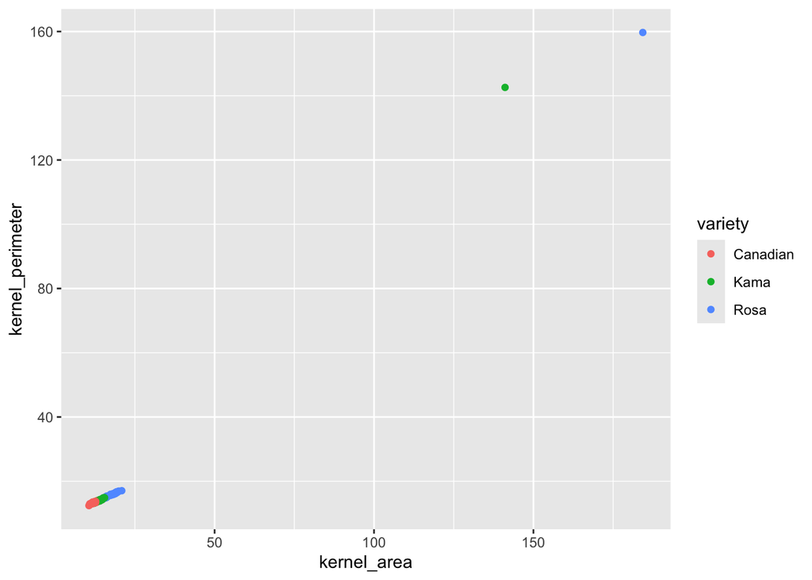

```r
wheat_train |>
  ggplot() +
  aes(x=kernel_area, y = kernel_perimeter, colour = variety) +
  geom_point()
```

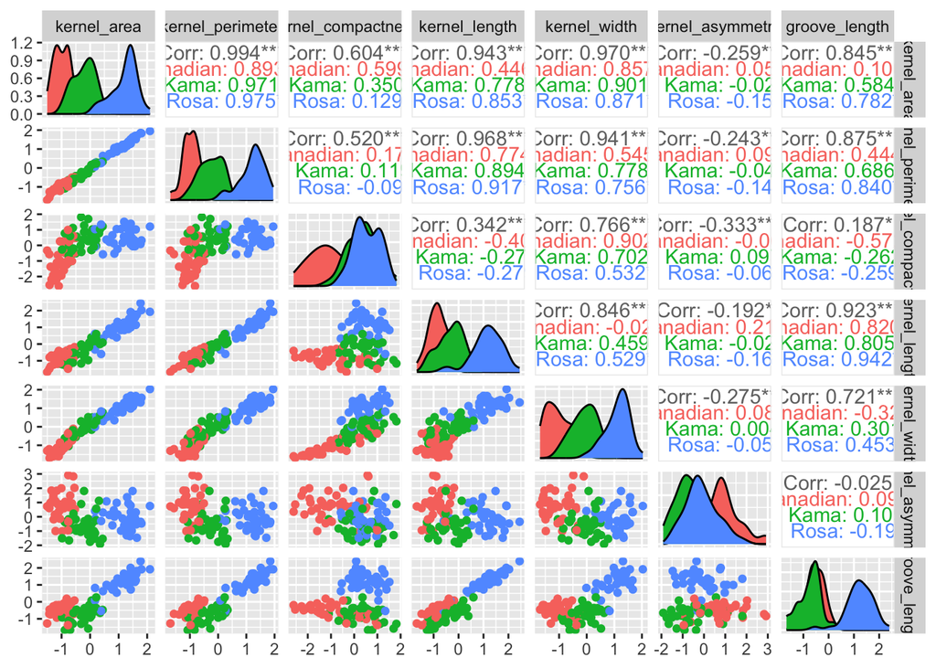

```r
wheat_train_clean <- wheat_train |>
  filter(kernel_area < 100)

#Normalise Recipe
all_recipe <- recipe(variety ~ ., data = wheat_train) |>
  step_normalize(all_numeric_predictors()) |>
  prep()

cleaner_recipe <- recipe(variety ~ ., data = wheat_train_clean) |>
  step_normalize(all_numeric_predictors()) |>
  prep()

wheat_train_all <- bake(all_recipe, new_data = wheat_train)
wheat_test_all  <- bake(all_recipe, new_data = wheat_test)

wheat_train_cleaner <- bake(cleaner_recipe, new_data = wheat_train_clean)
wheat_test_cleaner  <- bake(cleaner_recipe, new_data = wheat_test)


wheat_train_cleaner |>
  ggpairs(
    columns = 1:7,
    mapping = aes(colour = variety))
```

## Linear Discriminant Analysis

```r
set.seed(1414)

wheat_all.lda <- discrim_linear() |>
  fit(variety ~ ., data = wheat_train_all)

wheat_clean.lda <- discrim_linear() |>
  fit(variety ~ ., data = wheat_train_cleaner)

all_reduced_1.lda <- discrim_linear() |>
  fit(variety ~ . - kernel_perimeter - kernel_width - kernel_length,
      data = wheat_train_all)

clean_reduced_1.lda <- discrim_linear() |>
 fit(variety ~ . - kernel_perimeter - kernel_width - kernel_length,
      data = wheat_train_cleaner)


#prediction
all.lda.pred <- wheat_all.lda |>
  augment(new_data = wheat_test_all)

cleaner.lda.pred <- wheat_clean.lda |>
  augment(new_data = wheat_test_cleaner)

all.reduced.lda.pred <- all_reduced_1.lda |>
  augment(new_data = wheat_test_all)

cleaner.reduced.lda.pred <- clean_reduced_1.lda |>
  augment(new_data = wheat_test_cleaner)


#Confusion Matrix
all.lda.pred |>
  conf_mat(truth = variety, estimate = .pred_class)
```

```
##           Truth
## Prediction Canadian Kama Rosa
##   Canadian       12    0    1
##   Kama            1   12    0
##   Rosa            0    2   11
```

```r
cleaner.lda.pred |>
  conf_mat(truth = variety, estimate = .pred_class)
```

```
##           Truth
## Prediction Canadian Kama Rosa
##   Canadian       12    0    0
##   Kama            1   13    0
##   Rosa            0    1   12
```

```r
all.reduced.lda.pred |>
  conf_mat(truth = variety, estimate = .pred_class)
```

```
##           Truth
## Prediction Canadian Kama Rosa
##   Canadian       12    1    0
##   Kama            1   12    0
##   Rosa            0    1   12
```

```r
cleaner.reduced.lda.pred |>
  conf_mat(truth = variety, estimate = .pred_class)
```

```
##           Truth
## Prediction Canadian Kama Rosa
##   Canadian       12    0    0
##   Kama            0   12    0
##   Rosa            1    2   12
```

## Results

Linear Discriminant Analysis error rate: all.lda.pred = 10.3% Linear Discriminant Analysis error rate: cleaner.lda.pred = 5.1% Linear Discriminant Analysis error rate: all.reduced.lda.pred = 7.7% Linear Discriminant Analysis error rate: cleaner.reduced.lda.pred = 7.7%

## K-Nearest Neighbour Classification

```r
set.seed(1414)

all.knn <- nearest_neighbor(mode="classification", neighbors = 20) |>
  fit(variety ~ ., data = wheat_train_all)

cleaner.knn <- nearest_neighbor(mode="classification", neighbors = 20) |>
  fit(variety ~ ., data = wheat_train_cleaner)

all.reduced.knn <- nearest_neighbor(mode = "classification", neighbors = 20) |>
  fit(variety ~ . - kernel_perimeter - kernel_width - kernel_length,
      data = wheat_train_all)

cleaner.reduced.knn <- nearest_neighbor(mode = "classification", neighbors = 20) |>
  fit(variety ~ . - kernel_perimeter - kernel_width - kernel_length,
      data = wheat_train_cleaner)

#Prediction
all.knn.pred <- all.knn |>
  augment(new_data = wheat_test_all)

cleaner.knn.pred <- cleaner.knn |>
  augment(new_data = wheat_test_cleaner)

all_reduced.knn.pred <- all.reduced.knn |>
  augment(new_data = wheat_test_all)

cleaner_reduced.knn.pred <- cleaner.reduced.knn |>
  augment(new_data = wheat_test_cleaner)

#Confusion Matrix
all.knn.pred |>
  conf_mat(truth=variety, estimate=.pred_class)
```

```
##           Truth
## Prediction Canadian Kama Rosa
##   Canadian       12    1    0
##   Kama            0   11    0
##   Rosa            1    2   12
```

```r
cleaner.knn.pred |>
  conf_mat(truth=variety, estimate=.pred_class)
```

```
##           Truth
## Prediction Canadian Kama Rosa
##   Canadian       12    1    0
##   Kama            0   11    0
##   Rosa            1    2   12
```

```r
all_reduced.knn.pred |>
  conf_mat(truth=variety, estimate=.pred_class)
```

```
##           Truth
## Prediction Canadian Kama Rosa
##   Canadian       12    1    0
##   Kama            1   10    0
##   Rosa            0    3   12
```

```r
cleaner_reduced.knn.pred |>
  conf_mat(truth=variety, estimate=.pred_class)
```

```
##           Truth
## Prediction Canadian Kama Rosa
##   Canadian       10    2    0
##   Kama            2   10    0
##   Rosa            1    2   12
```

## Results

K-Nearest Neighbour error rate: all_wheat.knn.pred = 10.2% K-Nearest Neighbour error rate: cleaner_wheat.knn.pred = 10.2% K-Nearest Neighbour error rate: all_wheat.knn.pred = 12.8% K-Nearest Neighbour error rate: cleaner_wheat.knn.pred = 18%

```r
#Running best performing model on property test data
#adding .pred column to property.test and writing to a csv file
wheat.test2  <- bake(cleaner_recipe, new_data = wheat.test)

lda_pred_wheat.test <- wheat.test2 |>
  mutate(.pred = predict(wheat_clean.lda, new_data = wheat.test2)$.pred_class)

write_csv(lda_pred_wheat.test, "ex1_19034939.csv")
```

### 2.1 Wheat Variety Methodology

To predict variety for the wheat_test data, we split training data 75/25 for training prediction models.

Exploring the data we can see Kernel width, length, perimeter and area are all highly correlated with one another. The summary statistics, shows us there are moderate differences in predictor variables scales eg 0.76 - 184.3 and the max statistic for kernel_are and kernel_perimeter appear unusually high.

This is clear in the scatterplot, there are 2 outliers. To deal with this, wheat_train_clean, will remove observations greater than 100. Predictive accuracy can then be assessed by trialing different techniques to improve models.

To help balance the scales between variables, and reduce larger values from disproportionately dominating, a recipe is used to normalise each alternate version of data, (ie, transforming so the variables share similar mean/sd).

1: all data 2: clean data (no outliers)

The relationship between variables is clearer in the clean data pairs plot, coloured by wheat variety. There are generally distinctive differences in location, group means and spread of each variety. Kernel area, perimeter, length, and width show strong positive linear relationships.

Kernel asymmetry and compaction however show more overlap between varieties location and group means, with spread appearing more elliptical. With this an LDA may perform well on this data, although the strong correlations between variables could influence models stability.

3: kernel_area, kernel_compactness and groove length (both all and clean data)

As the relationship between predictors is not exclusively linear, KNN classification model will also be used alongside the LDA to compare accuracy. KNN is more flexible and resistant to non-linear differences in varieties, than LDA, however is sensitive to scaling. A larger than default, k= 20 value will be used to reduce the models sensitivity to noise, this may increase the models bias, but may reduce variance as a result. I expect KNN to perform better on all data or clean data, compared to the reduced predictors models due to its flexibility.

### 2.2 Wheat Variety Explainability

Using the cleaned training data in LDA, we can see LDA1 explains 75.9% of variance in variety types, with the most significant predictors as Kernal length (-4.02), Kernel Area (3.96), kernel_perimeter (2.49) and groove length (2.07). It appears wheat varieties are best differentiated by combined size measurements, we can see in earlier pairs plot, these predictors have clear distinct seperation between varieties, ie for kernel area, Canadian varieties peak at small values, Kama peaks at mid values, and Rosa at higher values, the means for each variety groups are distinct.

```r
print(wheat_clean.lda)
```

```
## parsnip model object
##
## Call:
## lda(variety ~ ., data = data)
##
## Prior probabilities of groups:
##  Canadian      Kama      Rosa
## 0.3391304 0.3217391 0.3391304
##
## Group means:
##          kernel_area kernel_perimeter kernel_compactness kernel_length
## Canadian  -1.0049632       -0.9792508         -0.9058320    -0.8657475
## Kama      -0.2201063       -0.2545453          0.3763649    -0.3199882
## Rosa       1.2137820        1.2207424          0.5487679     1.1693260
##          kernel_width kernel_asymmetry groove_length
## Canadian  -1.05076845        0.7120762    -0.5304975
## Kama      -0.07672772       -0.6372525    -0.7410925
## Rosa       1.12356141       -0.1075033     1.2335852
##
## Coefficients of linear discriminants:
##                            LD1        LD2
## kernel_area         3.96323652  8.7096428
## kernel_perimeter    2.49507923 -8.5247456
## kernel_compactness -0.18142179 -2.0109917
## kernel_length      -4.02040257 -3.2653023
## kernel_width       -1.41709622  1.0104074
## kernel_asymmetry    0.06500581  0.4522501
## groove_length       2.07653703  3.1269397
##
## Proportion of trace:
##    LD1    LD2
## 0.7594 0.2406
```